# 14. 작업 1유형 - 3

```python
import pandas as pd

df= pd.read_csv('https://raw.githubusercontent.com/Datamanim/datarepo/main/worldcup/worldcupgoals.csv')
df.head()
```

|  | Player | Goals | Years | Country |
| --- | --- | --- | --- | --- |
| 0 | Miroslav Klose | 16 | 2002-2006-2010-2014 | Germany |
| 1 | Ronaldo | 15 | 1998-2002-2006 | Brazil |
| 2 | Gerd Muller | 14 | 1970-1974 | Germany |
| 3 | Just Fontaine | 13 | 1958 | France |
| 4 | Pele | 12 | 1958-1962-1966-1970 | Brazil |

## 1. 주어진 전체 기간의 각 나라별 골득점수 상위 5개 국가와 그 득점수를 데이터프레임형태로 출력

```python
df.groupby(df['Country'],as_index=False).Goals.sum().sort_values('Goals',ascending=False).set_index('Country',drop=True).head()
```

| Country | Goals |
| --- | --- |
| Brazil | 228 |
| Germany | 226 |
| Argentina | 135 |
| Italy | 123 |
| France | 115 |

## 2. 주어진 전체기간동안 골득점을 한 선수가 가장 많은 나라 상위 5개 국가와 그 선수 숫자를 데이터 프레임 형식으로 출력

```python
df.groupby(df['Country'],as_index=False).Player.count().sort_values('Player',ascending=False).head()
```

|  | Country | Player |
| --- | --- | --- |
| 8 | Brazil | 81 |
| 25 | Germany | 78 |
| 36 | Italy | 60 |
| 2 | Argentina | 59 |
| 24 | France | 58 |

## 3. 년도 표기가 4자리 숫자로 안된 케이스가 몇건인지 출력

```python
df
```

|  | Player | Goals | Years | Country |
| --- | --- | --- | --- | --- |
| 0 | Miroslav Klose | 16 | 2002-2006-2010-2014 | Germany |
| 1 | Ronaldo | 15 | 1998-2002-2006 | Brazil |
| 2 | Gerd Muller | 14 | 1970-1974 | Germany |
| 3 | Just Fontaine | 13 | 1958 | France |
| 4 | Pele | 12 | 1958-1962-1966-1970 | Brazil |
| ... | ... | ... | ... | ... |
| 1290 | Josip Skoblar | 1 | 1962 | Yugoslavia |
| 1291 | Safet Susic | 1 | 1982-1990 | Yugoslavia |
| 1292 | Aleksandar Tirnanic | 1 | 1930 | Yugoslavia |
| 1293 | Djordje Vujadinovic | 1 | 1930 | Yugoslavia |
| 1294 | Branko Zebec | 1 | 1954-1958 | Yugoslavia |

1295 rows × 4 columns

```python
# 4자리 숫자로 안된 케이스

df['YearDesi'] = df['Years'].str.split('-')

c = 0

for i in range(len(df['YearDesi'])):
    for j in range(len(df['YearDesi'][i])):
        if len(df['YearDesi'][i][j]) != 4:
            c += 1

c
```

```
45
```

# 4. 3에서 발생한 예외 케이스를 제외한 데이터프레임을 df2라고 정의하고 데이터의 행의 숫자를 출력

```python
df['is'] = 0

for i in range(len(df['YearDesi'])):
    c = 0
    for j in range(len(df['YearDesi'][i])):
        if len(df['YearDesi'][i][j]) != 4:
            c += 1
    if c != 0:
        df.iloc[i,5] = 1

df
```

|  | Player | Goals | Years | Country | YearDesi | is |
| --- | --- | --- | --- | --- | --- | --- |
| 0 | Miroslav Klose | 16 | 2002-2006-2010-2014 | Germany | [2002, 2006, 2010, 2014] | 0 |
| 1 | Ronaldo | 15 | 1998-2002-2006 | Brazil | [1998, 2002, 2006] | 0 |
| 2 | Gerd Muller | 14 | 1970-1974 | Germany | [1970, 1974] | 0 |
| 3 | Just Fontaine | 13 | 1958 | France | [1958] | 0 |
| 4 | Pele | 12 | 1958-1962-1966-1970 | Brazil | [1958, 1962, 1966, 1970] | 0 |
| ... | ... | ... | ... | ... | ... | ... |
| 1290 | Josip Skoblar | 1 | 1962 | Yugoslavia | [1962] | 0 |
| 1291 | Safet Susic | 1 | 1982-1990 | Yugoslavia | [1982, 1990] | 0 |
| 1292 | Aleksandar Tirnanic | 1 | 1930 | Yugoslavia | [1930] | 0 |
| 1293 | Djordje Vujadinovic | 1 | 1930 | Yugoslavia | [1930] | 0 |
| 1294 | Branko Zebec | 1 | 1954-1958 | Yugoslavia | [1954, 1958] | 0 |

1295 rows × 6 columns

```python
# 4자리 숫자로 안된 케이스를 가진 행

df['is'][df['is'] == 1].count()
```

```
45
```

```python
df2 = df[df['is'] == 0].reset_index(drop=True).iloc[:,0:6]
df2
```

|  | Player | Goals | Years | Country | YearDesi | is |
| --- | --- | --- | --- | --- | --- | --- |
| 0 | Miroslav Klose | 16 | 2002-2006-2010-2014 | Germany | [2002, 2006, 2010, 2014] | 0 |
| 1 | Ronaldo | 15 | 1998-2002-2006 | Brazil | [1998, 2002, 2006] | 0 |
| 2 | Gerd Muller | 14 | 1970-1974 | Germany | [1970, 1974] | 0 |
| 3 | Just Fontaine | 13 | 1958 | France | [1958] | 0 |
| 4 | Pele | 12 | 1958-1962-1966-1970 | Brazil | [1958, 1962, 1966, 1970] | 0 |
| ... | ... | ... | ... | ... | ... | ... |
| 1245 | Josip Skoblar | 1 | 1962 | Yugoslavia | [1962] | 0 |
| 1246 | Safet Susic | 1 | 1982-1990 | Yugoslavia | [1982, 1990] | 0 |
| 1247 | Aleksandar Tirnanic | 1 | 1930 | Yugoslavia | [1930] | 0 |
| 1248 | Djordje Vujadinovic | 1 | 1930 | Yugoslavia | [1930] | 0 |
| 1249 | Branko Zebec | 1 | 1954-1958 | Yugoslavia | [1954, 1958] | 0 |

1250 rows × 6 columns

```python
df2.shape[0]
```

```
1250
```

## 5. 월드컵 출전횟수를 나타내는 ‘LenCup’ 컬럼을 추가하고 4회 출전한 선수의 숫자

```python
df2['LenCup'] = 0
df2
```

|  | Player | Goals | Years | Country | YearDesi | is | LenCup |
| --- | --- | --- | --- | --- | --- | --- | --- |
| 0 | Miroslav Klose | 16 | 2002-2006-2010-2014 | Germany | [2002, 2006, 2010, 2014] | 0 | 0 |
| 1 | Ronaldo | 15 | 1998-2002-2006 | Brazil | [1998, 2002, 2006] | 0 | 0 |
| 2 | Gerd Muller | 14 | 1970-1974 | Germany | [1970, 1974] | 0 | 0 |
| 3 | Just Fontaine | 13 | 1958 | France | [1958] | 0 | 0 |
| 4 | Pele | 12 | 1958-1962-1966-1970 | Brazil | [1958, 1962, 1966, 1970] | 0 | 0 |
| ... | ... | ... | ... | ... | ... | ... | ... |
| 1245 | Josip Skoblar | 1 | 1962 | Yugoslavia | [1962] | 0 | 0 |
| 1246 | Safet Susic | 1 | 1982-1990 | Yugoslavia | [1982, 1990] | 0 | 0 |
| 1247 | Aleksandar Tirnanic | 1 | 1930 | Yugoslavia | [1930] | 0 | 0 |
| 1248 | Djordje Vujadinovic | 1 | 1930 | Yugoslavia | [1930] | 0 | 0 |
| 1249 | Branko Zebec | 1 | 1954-1958 | Yugoslavia | [1954, 1958] | 0 | 0 |

1250 rows × 7 columns

```python
len(df2['YearDesi'][0])
```

```
4
```

```python
df2['LenCup'] = df2['YearDesi'].apply(len)

df2
```

|  | Player | Goals | Years | Country | YearDesi | is | LenCup |
| --- | --- | --- | --- | --- | --- | --- | --- |
| 0 | Miroslav Klose | 16 | 2002-2006-2010-2014 | Germany | [2002, 2006, 2010, 2014] | 0 | 4 |
| 1 | Ronaldo | 15 | 1998-2002-2006 | Brazil | [1998, 2002, 2006] | 0 | 3 |
| 2 | Gerd Muller | 14 | 1970-1974 | Germany | [1970, 1974] | 0 | 2 |
| 3 | Just Fontaine | 13 | 1958 | France | [1958] | 0 | 1 |
| 4 | Pele | 12 | 1958-1962-1966-1970 | Brazil | [1958, 1962, 1966, 1970] | 0 | 4 |
| ... | ... | ... | ... | ... | ... | ... | ... |
| 1245 | Josip Skoblar | 1 | 1962 | Yugoslavia | [1962] | 0 | 1 |
| 1246 | Safet Susic | 1 | 1982-1990 | Yugoslavia | [1982, 1990] | 0 | 2 |
| 1247 | Aleksandar Tirnanic | 1 | 1930 | Yugoslavia | [1930] | 0 | 1 |
| 1248 | Djordje Vujadinovic | 1 | 1930 | Yugoslavia | [1930] | 0 | 1 |
| 1249 | Branko Zebec | 1 | 1954-1958 | Yugoslavia | [1954, 1958] | 0 | 2 |

1250 rows × 7 columns

```python
df2['LenCup'][df2['LenCup'] == 4].count()
```

```
16
```

## 6. Yugoslavia 국가의 월드컵 출전횟수가 2회인 선수들의 수

```python
df2['Player'][(df2['Country'] =='Yugoslavia') & (df2['LenCup'] == 2)].count()
```

```
7
```

## 7. 2002년도에 출전한 전체 선수의 수

```python
df['Player'][df['YearDesi'].apply(lambda x: '2002' in x)].count()
```

```
156
```

## 8. 이름에 ‘carlos’ 단어가 들어가는 선수들의 수

```python
len(df2[df2['Player'].str.lower().str.contains('carlos')])
```

```
13
```

# 9. 월드컵 출전 횟수가 1회뿐인 선수들 중에서 가장 많은 득점을 올렸던 선수

```python
print(df2[df2['YearDesi'].apply(len) == 1].sort_values('Goals',ascending = False).Player.iloc[0])
```

```
Just Fontaine
```

## 10. 월드컵 출전횟수가 1회 뿐인 선수들이 가장 많은 국가

```python
df2[df2['LenCup'] == 1].Country.value_counts().index[0]
```

```
'Brazil'
```

## 번외: 분석 및 시각화

```python
df= pd.read_csv('https://raw.githubusercontent.com/Datamanim/datarepo/main/worldcup/worldcupgoals.csv')
```

```python
df.info()
```

```
<class 'pandas.core.frame.DataFrame'>
RangeIndex: 1295 entries, 0 to 1294
Data columns (total 4 columns):
 #   Column   Non-Null Count  Dtype
---  ------   --------------  -----
 0   Player   1295 non-null   object
 1   Goals    1295 non-null   int64
 2   Years    1295 non-null   object
 3   Country  1295 non-null   object
dtypes: int64(1), object(3)
memory usage: 40.6+ KB
```

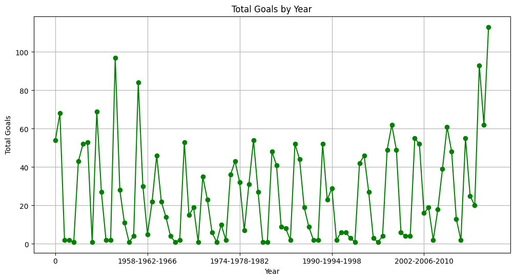

```python
import matplotlib.pyplot as plt


df['Years'] = df['Years'].astype(str)
yearly_goals = df.groupby('Years')['Goals'].sum()


plt.figure(figsize=(12, 6))
yearly_goals.plot(kind='line', marker='o', color='green')
plt.title('Total Goals by Year')
plt.xlabel('Year')
plt.ylabel('Total Goals')
plt.grid(True)
plt.show()
```

#### 추가 질문: 총 골의 수와 관람객 사이에 상관관계가 존재할까?